# Quality and Index Swapping Analysis

Adrian Bubie

9/11/17

### Goals: Determine if index swapping occurred in our Hiseq4000 class sequencing samples.

De-multiplex samples to create 48 FASTQ files that contain acceptable index pairs (read1 and read2) and two files of undetermined files that contain unacceptable index pairs, low quality, or undetermined (read1 and read2).

1. (Please see the associated python script, “Qual_Mean_Calc.py” for reference on how the files used to plot here were created).

Quality plots per basepair position and distribution of average quality score per read, for each of our 4 input files (read1, read2, index1, index2):

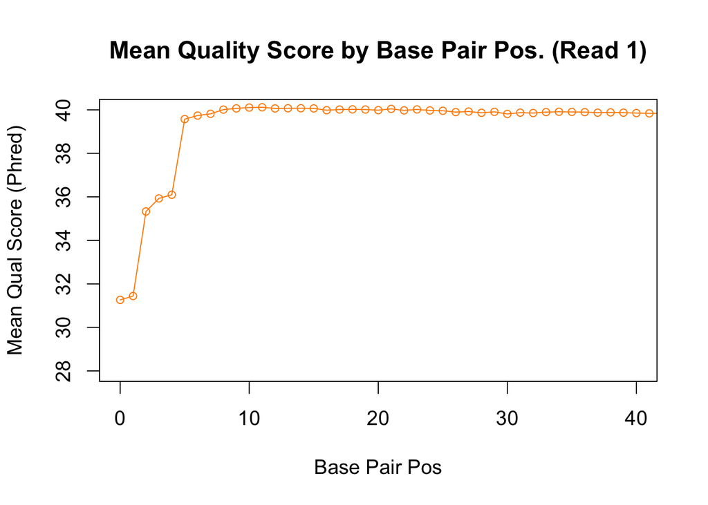

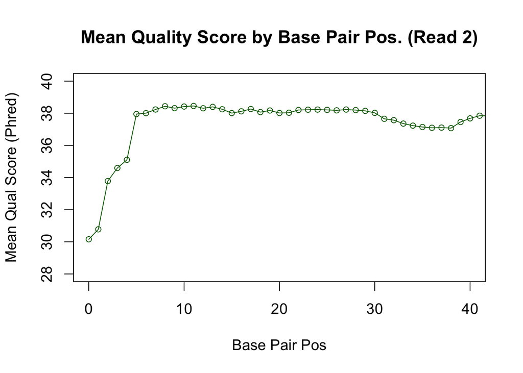

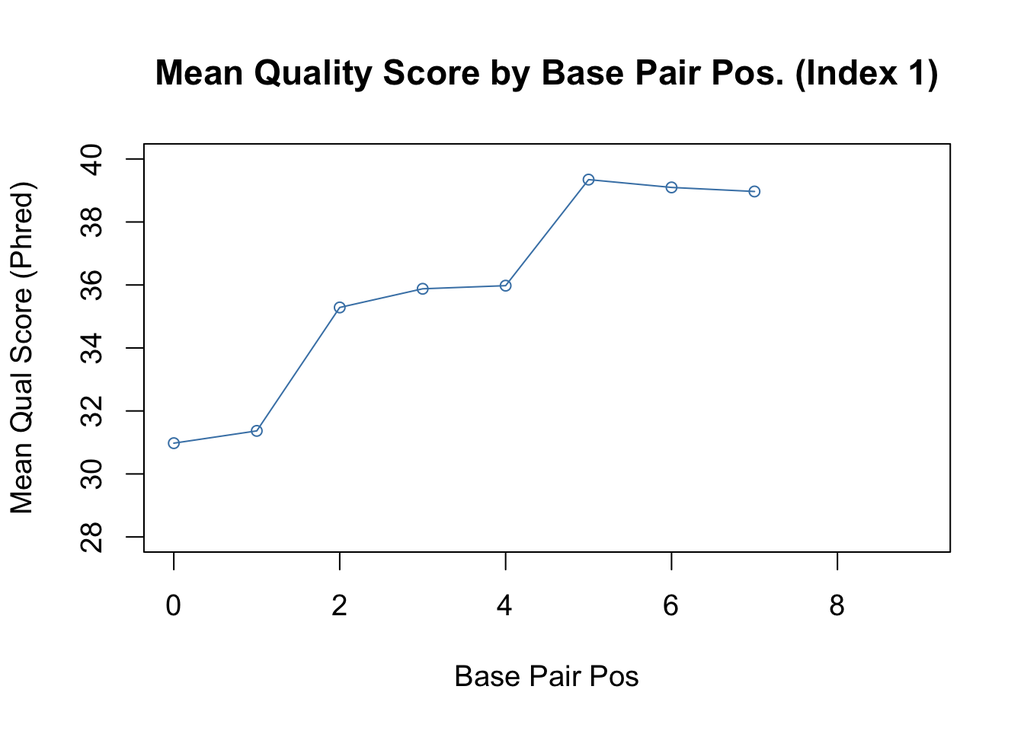

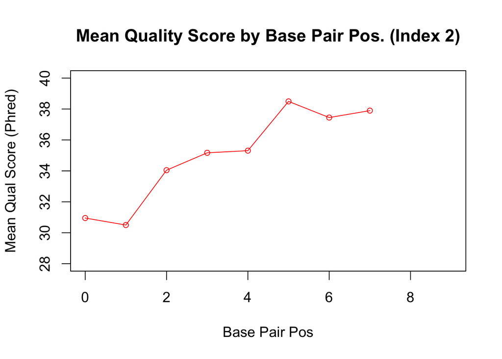

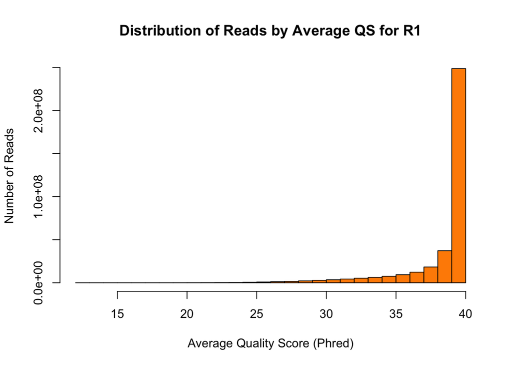

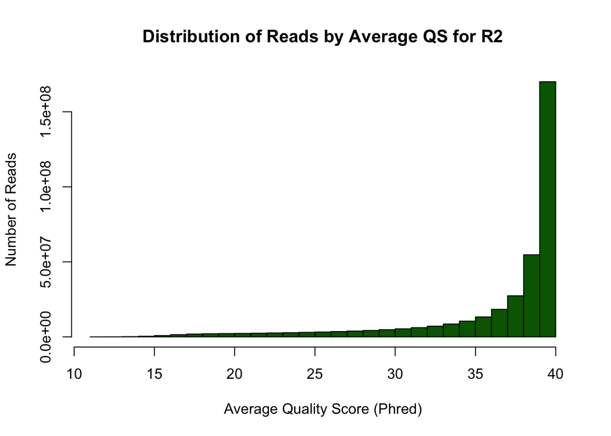

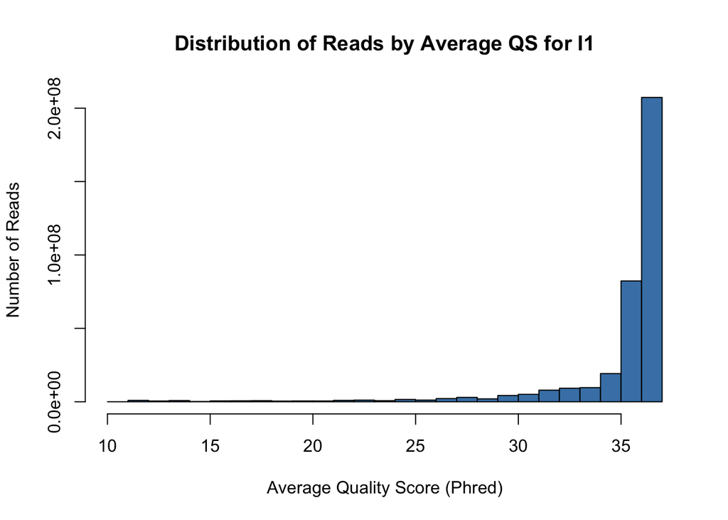

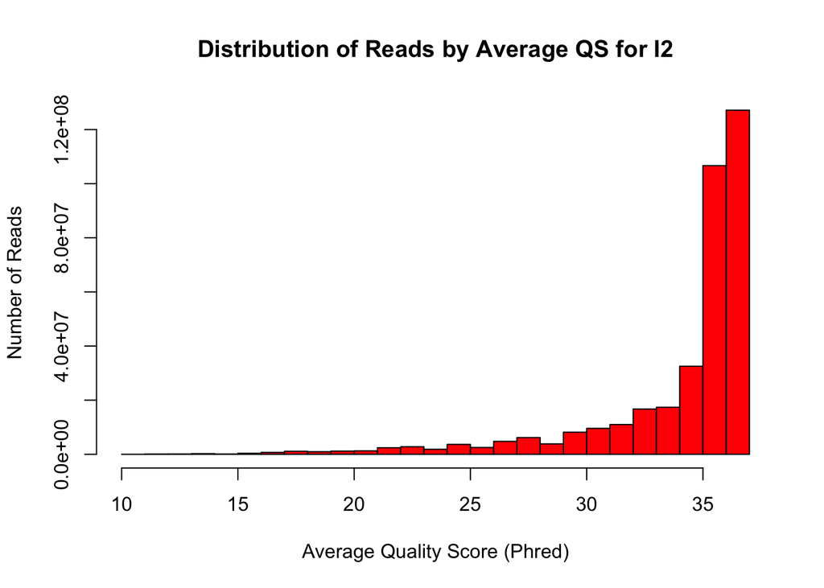

From these distributions, we can most likely set a quality cutoff of 35 for the index pairs and quality cutoff of 37 for our paired reads, and retain about 3/4 (about 250 million) of our reads, while improving the quality of our reads overall.